# Distributed Data Analysis Using sparklyr - Part II

Biostat M280

Dr. Hua Zhou

Feb 27, 2018

In this tutorial, we do some exploratory data analysis of the distributed data in a Hadoop YARN cluster. Again it is adapted from the [tutorial at RStudio](http://spark.rstudio.com/examples/yarn-cluster-emr/).

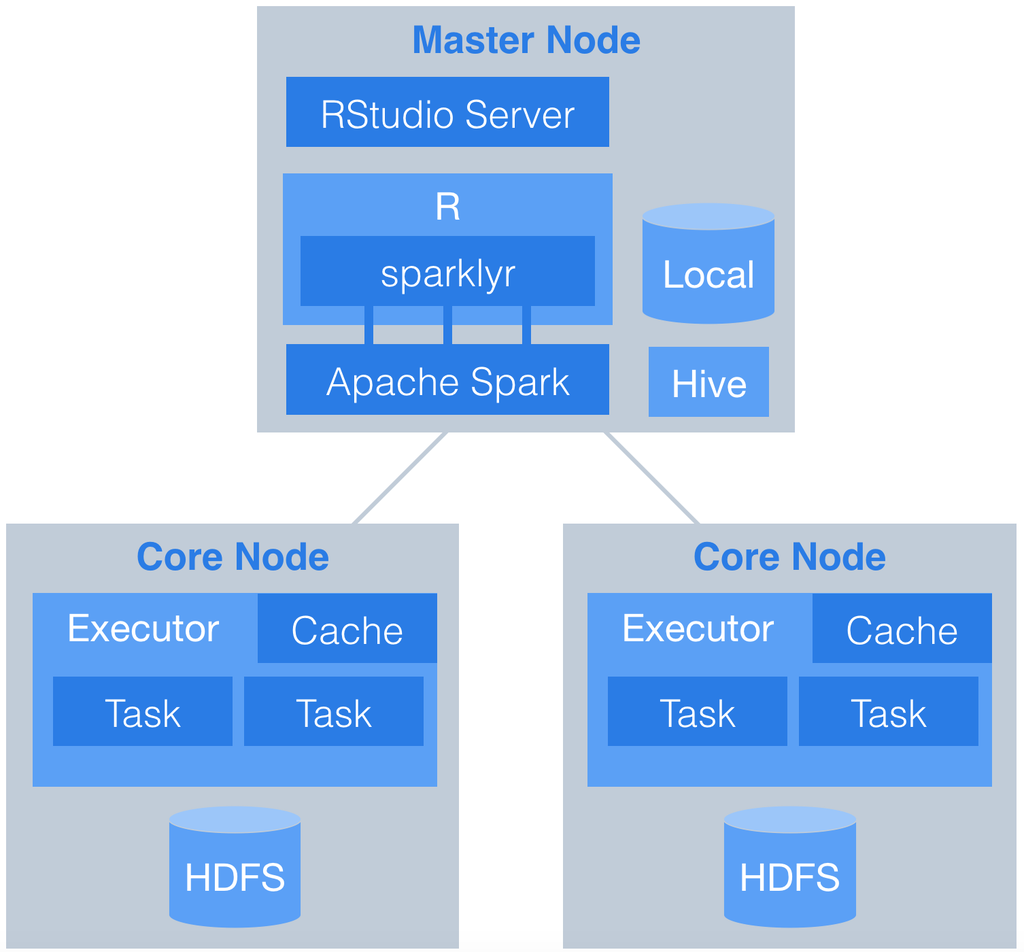

## Log in the Hadoop YARN cluster

- GCP YARN cluster master node has IP address `35.185.198.142` and is serving RStudio at [`http://35.185.198.142:8787`](http://35.185.198.142:8787).

[figure not shown]

- Your username is same as on the teaching server and the default password is `m280`. Change password via `passwd` command immediately after your first login. Again setting up SSH key authentication will make our life easier.
- To work on your HW4 on the YARN master node, you may first `git clone` your `biostat-m280-2018-winter` repo and create a project.
- `tidyverse`, `DBI`, `sparklyr` are already installed globally so you don’t have to install them.

## Connect to Spark

```r
# Connect to Spark
library(sparklyr)
library(dplyr)
```

```r
library(ggplot2)
Sys.setenv(SPARK_HOME="/usr/lib/spark")
config <- spark_config()
sc <- spark_connect(master = "yarn-client", config = config)
sc
```

```
## $master
## [1] "yarn-client"
##
## $method
## [1] "shell"
##
## $app_name
## [1] "sparklyr"
##
## $config
## $config$spark.env.SPARK_LOCAL_IP.local
## [1] "127.0.0.1"
##
## $config$sparklyr.csv.embedded
## [1] "^1.*"
##
## $config$sparklyr.cores.local
## [1] 8
##
## $config$spark.sql.shuffle.partitions.local
## [1] 8
##
## attr(,"config")
## [1] "default"
## attr(,"file")
## [1] "/usr/local/lib/R/site-library/sparklyr/conf/config-template.yml"
##
## $spark_home
## [1] "/usr/lib/spark"
##
## $backend
##         description               class                mode
## "->localhost:34211"          "sockconn"                "wb"
##                text              opened            can read
##            "binary"            "opened"               "yes"
##           can write
##               "yes"
##
## $monitor
##        description              class               mode
## "->localhost:8880"         "sockconn"               "rb"
##               text             opened           can read
##           "binary"           "opened"              "yes"
##          can write
##              "yes"
##
## $output_file
## [1] "/tmp/RtmpfnJSi4/filebb91287480f_spark.log"
##
## $spark_context
## <jobj[6]>
##   org.apache.spark.SparkContext
##   org.apache.spark.SparkContext@52bb0e70
##
## $java_context
## <jobj[7]>
##   org.apache.spark.api.java.JavaSparkContext
##   org.apache.spark.api.java.JavaSparkContext@2ed07152
##
## attr(,"class")
## [1] "spark_connection"       "spark_shell_connection"
## [3] "DBIConnection"
```

## Access Hive tables

Create dplyr reference to the Spark DataFrame.

```r
# Cache flights Hive table into Spark
#tbl_cache(sc, 'flights')
flights_tbl <- tbl(sc, 'flights')
flights_tbl %>% print(width = Inf)
```

```
## # Source:   table<flights> [?? x 29]
## # Database: spark_connection
##     year month dayofmonth dayofweek deptime crsdeptime arrtime crsarrtime
##    <int> <int>      <int>     <int>   <int>      <int>   <int>      <int>
##  1    NA    NA         NA        NA      NA         NA      NA         NA
##  2  1987    10         14         3     741        730     912        849
##  3  1987    10         15         4     729        730     903        849
##  4  1987    10         17         6     741        730     918        849
##  5  1987    10         18         7     729        730     847        849
##  6  1987    10         19         1     749        730     922        849
##  7  1987    10         21         3     728        730     848        849
##  8  1987    10         22         4     728        730     852        849
##  9  1987    10         23         5     731        730     902        849
## 10  1987    10         24         6     744        730     908        849
##    uniquecarrier flightnum tailnum actualelapsedtime crselapsedtime
```

[output cut: 48 more lines]

```r
# Cache airlines Hive table into Spark
#tbl_cache(sc, 'airlines')
airlines_tbl <- tbl(sc, 'airlines')
airlines_tbl %>% print(width = Inf)
```

```
## # Source:   table<airlines> [?? x 2]
## # Database: spark_connection
##    code  description
##    <chr> <chr>
##  1 Code  Description
##  2 02Q   Titan Airways
##  3 04Q   Tradewind Aviation
##  4 05Q   Comlux Aviation, AG
##  5 06Q   Master Top Linhas Aereas Ltd.
##  6 07Q   Flair Airlines Ltd.
##  7 09Q   Swift Air, LLC d/b/a Eastern Air Lines d/b/a Eastern
##  8 0BQ   DCA
##  9 0CQ   ACM AIR CHARTER GmbH
## 10 0FQ   Maine Aviation Aircraft Charter, LLC
## # ... with more rows
```

```r
# Cache airports Hive table into Spark
#tbl_cache(sc, 'airports')
airports_tbl <- tbl(sc, 'airports')
airports_tbl %>% print(width = Inf)
```

```
## # Source:   table<airports> [?? x 12]
## # Database: spark_connection
##    id    name                                        city
##    <chr> <chr>                                       <chr>
##  1 1     Goroka Airport                              Goroka
##  2 2     Madang Airport                              Madang
##  3 3     Mount Hagen Kagamuga Airport                Mount Hagen
##  4 4     Nadzab Airport                              Nadzab
##  5 5     Port Moresby Jacksons International Airport Port Moresby
##  6 6     Wewak International Airport                 Wewak
##  7 7     Narsarsuaq Airport                          Narssarssuaq
##  8 8     Godthaab / Nuuk Airport                     Godthaab
##  9 9     Kangerlussuaq Airport                       Sondrestrom
## 10 10    Thule Air Base                              Thule
##    country          faa   icao  lat                lon
```

[output cut: 24 more lines]

## How many data points

Across whole data set:

```r
system.time({
out <- flights_tbl %>%
  group_by(year) %>%
  count() %>%
  arrange(year) %>%
  collect()
})
```

```
##    user  system elapsed
##   0.024   0.004  34.601
```

```r
out
```

```
## # A tibble: 23 x 2
## # Groups:   year [23]
##     year        n
##    <int>    <dbl>
##  1    NA      22.
##  2  1987 1311826.
##  3  1988 5202096.
##  4  1989 5041200.
##  5  1990 5270893.
##  6  1991 5076925.
##  7  1992 5092157.
##  8  1993 5070501.
##  9  1994 5180048.
## 10  1995 5327435.
## # ... with 13 more rows
```

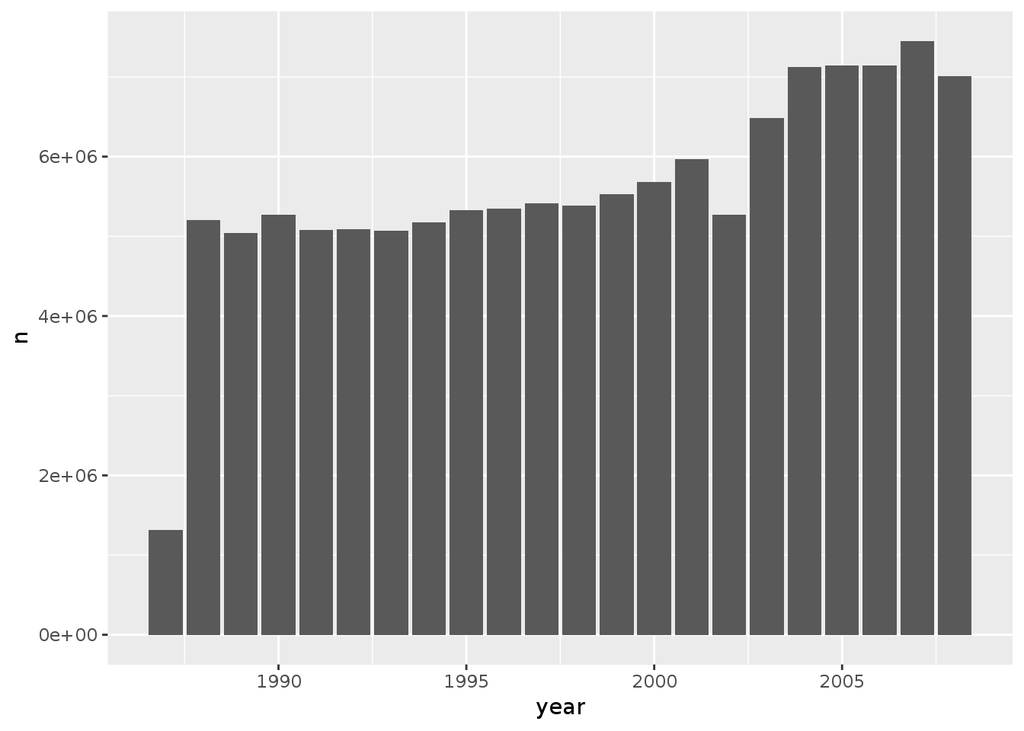

```r
out %>% ggplot(aes(x = year, y = n)) + geom_col()
```

How many flights from LAX per year:

```r
system.time({
out <- flights_tbl %>%
  filter(origin == "LAX") %>%
  group_by(year) %>%
  count() %>%
  arrange(year) %>%
  collect()
})
```

```
##    user  system elapsed
##   0.024   0.000  32.768
```

```r
out
```

```
## # A tibble: 22 x 2
## # Groups:   year [22]
##     year       n
##    <int>   <dbl>
##  1  1987  45646.
##  2  1988 169696.
##  3  1989 163487.
##  4  1990 169847.
##  5  1991 156947.
##  6  1992 155639.
##  7  1993 152353.
##  8  1994 153494.
##  9  1995 179909.
## 10  1996 184108.
## # ... with 12 more rows
```

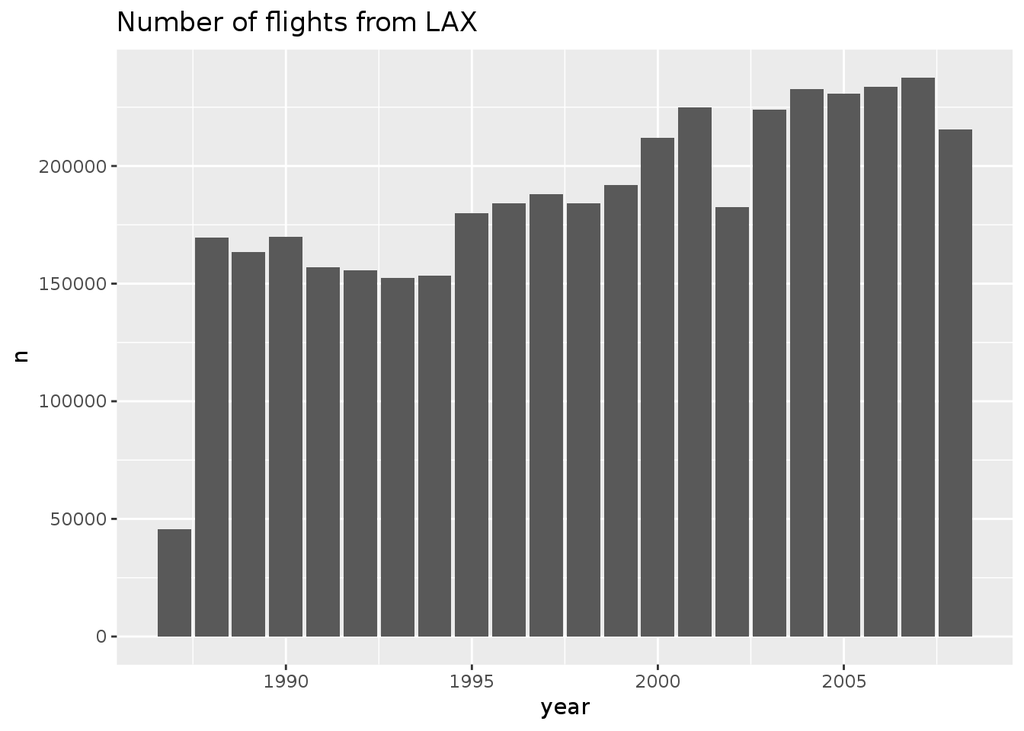

```r
out %>% ggplot(aes(x = year, y = n)) +
    geom_col() +
    labs(title = "Number of flights from LAX")
```

How many flights to LAX per year:

```r
system.time({
out <- flights_tbl %>%
  filter(dest == "LAX") %>%
  group_by(year) %>%
  count() %>%
  arrange(year) %>%
  collect()
})
```

```
##    user  system elapsed
##   0.024   0.000  34.139
```

```r
out
```

```
## # A tibble: 22 x 2
## # Groups:   year [22]
##     year       n
##    <int>   <dbl>
##  1  1987  45597.
##  2  1988 169699.
##  3  1989 162763.
##  4  1990 169449.
##  5  1991 156845.
##  6  1992 155270.
##  7  1993 151456.
##  8  1994 152959.
##  9  1995 179950.
## 10  1996 184128.
## # ... with 12 more rows
```

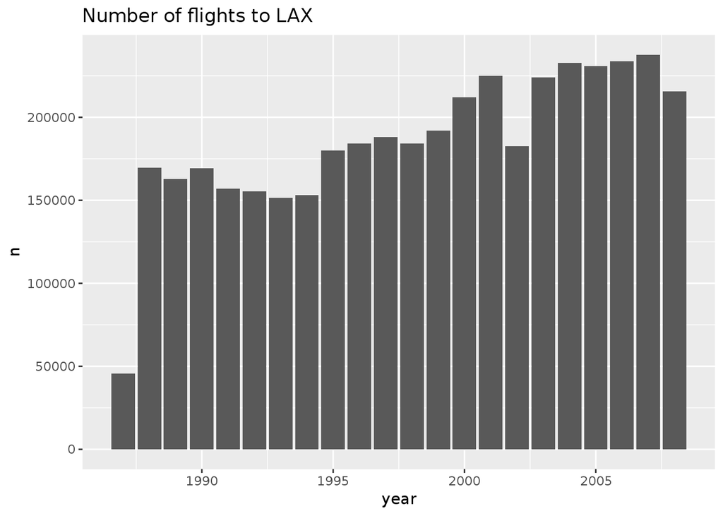

```r
out %>% ggplot(aes(x = year, y = n)) +
    geom_col() +
    labs(title = "Number of flights to LAX")
```

## Create a model data set

Suppose we want to fit a linear regression of `gain` (`depdelay` - `arrdelay`) on distance, departure delay, and carriers using data from 2003-2007.

```r
# Filter records and create target variable 'gain'
system.time(
  model_data <- flights_tbl %>%
    filter(!is.na(arrdelay) & !is.na(depdelay) & !is.na(distance)) %>%
    filter(depdelay > 15 & depdelay < 240) %>%
    filter(arrdelay > -60 & arrdelay < 360) %>%
    filter(year >= 2003 & year <= 2007) %>%
    left_join(airlines_tbl, by = c("uniquecarrier" = "code")) %>%
    mutate(gain = depdelay - arrdelay) %>%
    select(year, month, arrdelay, depdelay, distance, uniquecarrier, description, gain)
)
```

```
##    user  system elapsed
##   0.004   0.000   0.004
```

```r
model_data
```

```
## # Source:   lazy query [?? x 8]
## # Database: spark_connection
##     year month arrdelay depdelay distance uniquecarrier description   gain
##    <int> <int>    <int>    <int>    <int> <chr>         <chr>        <int>
##  1  2003     1       23       29      837 UA            United Air …     6
##  2  2003     1       52       18     1835 UA            United Air …   -34
##  3  2003     1       64       82      413 UA            United Air …    18
##  4  2003     1       54       38      413 UA            United Air …   -16
##  5  2003     1        5       17      413 UA            United Air …    12
##  6  2003     1      132      126      413 UA            United Air …    -6
##  7  2003     1        7       29     1723 UA            United Air …    22
##  8  2003     1       62       77     1723 UA            United Air …    15
##  9  2003     1      148      135     1723 UA            United Air …   -13
## 10  2003     1      101       97     1723 UA            United Air …    -4
## # ... with more rows
```

```r
# Summarize data by carrier
model_data %>%
  group_by(uniquecarrier) %>%
  summarize(description = min(description), gain = mean(gain),
            distance = mean(distance), depdelay = mean(depdelay)) %>%
  select(description, gain, distance, depdelay) %>%
  arrange(gain)
```

```
## # Source:     lazy query [?? x 4]
## # Database:   spark_connection
## # Ordered by: gain
##    description                    gain distance depdelay
##    <chr>                         <dbl>    <dbl>    <dbl>
##  1 ATA Airlines d/b/a ATA       -3.35     1135.     56.1
##  2 ExpressJet Airlines Inc. (1) -3.03      520.     59.4
##  3 Envoy Air                    -2.54      416.     53.1
##  4 Northwest Airlines Inc.      -2.20      779.     48.5
##  5 Delta Air Lines Inc.         -1.82      868.     50.8
##  6 AirTran Airways Corporation  -1.43      642.     55.0
##  7 Continental Air Lines Inc.   -0.962    1117.     57.0
##  8 American Airlines Inc.       -0.886    1074.     55.5
##  9 Endeavor Air Inc.            -0.639     467.     58.5
## 10 JetBlue Airways              -0.326    1139.     54.1
## # ... with more rows
```

## Train a linear model

Predict time gained or lost in flight as a function of distance, departure delay, and airline carrier.

```r
# Partition the data into training and validation sets
model_partition <- model_data %>%
  sdf_partition(train = 0.8, valid = 0.2, seed = 5555)

# Fit a linear model
system.time(
  ml1 <- model_partition$train %>%
    ml_linear_regression(gain ~ distance + depdelay + uniquecarrier)
)
```

```
##    user  system elapsed
##   0.172   0.008 357.332
```

```r
# Summarize the linear model
summary(ml1)
```

```
## Call: ml_linear_regression.tbl_spark(., gain ~ distance + depdelay + uniquecarrier)
##
## Deviance Residuals (approximate):
##      Min       1Q   Median       3Q      Max
## -235.915   -5.484    2.732    9.853  103.617
##
## Coefficients:
##      (Intercept)         distance         depdelay uniquecarrier_WN
##      1.744310610      0.003265998     -0.014662325      0.876124221
## uniquecarrier_AA uniquecarrier_MQ uniquecarrier_UA uniquecarrier_DL
##     -5.314241548     -4.870711724     -3.670680336     -5.676217564
## uniquecarrier_US uniquecarrier_OO uniquecarrier_EV uniquecarrier_NW
##     -3.603629208     -2.367797953     -1.052889012     -5.783125644
## uniquecarrier_XE uniquecarrier_CO uniquecarrier_OH uniquecarrier_FL
##     -5.584317607     -5.513917180     -2.152535205     -4.454803437
## uniquecarrier_AS uniquecarrier_DH uniquecarrier_YV uniquecarrier_B6
##     -2.067187427     -0.754864480      0.123395029     -4.945583357
## uniquecarrier_HP uniquecarrier_9E uniquecarrier_F9 uniquecarrier_TZ
##     -0.894187818     -2.987736373     -3.885617746     -7.986040267
## uniquecarrier_HA
##     -3.132802810
##
## R-Squared: 0.02385
## Root Mean Squared Error: 17.74
```

## Assess model performance

Compare the model performance using the validation data.

```r
# Calculate average gains by predicted decile
system.time(
  model_deciles <- lapply(model_partition, function(x) {
    sdf_predict(ml1, x) %>%
      mutate(decile = ntile(desc(prediction), 10)) %>%
      group_by(decile) %>%
      summarize(gain = mean(gain)) %>%
      select(decile, gain) %>%
      collect()
  })
)
```

```
##    user  system elapsed
##   0.120   0.000 125.857
```

```r
model_deciles
```

```
## $train
## # A tibble: 10 x 2
##    decile   gain
##     <int>  <dbl>
##  1      1  6.02
##  2      2  2.48
##  3      3  1.71
##  4      4  1.07
##  5      5  0.337
##  6      6 -0.343
##  7      7 -1.23
##  8      8 -2.25
##  9      9 -2.70
## 10     10 -3.78
##
## $valid
## # A tibble: 10 x 2
##    decile   gain
##     <int>  <dbl>
##  1      1  5.97
##  2      2  2.51
##  3      3  1.64
##  4      4  1.06
##  5      5  0.385
##  6      6 -0.498
##  7      7 -1.15
##  8      8 -2.27
##  9      9 -2.71
## 10     10 -3.83
```

```r
# Create a summary dataset for plotting
deciles <- rbind(
  data.frame(data = 'train', model_deciles$train),
  data.frame(data = 'valid', model_deciles$valid),
  make.row.names = FALSE
)
deciles
```

```
##     data decile       gain
## 1  train      1  6.0198019
## 2  train      2  2.4791083
## 3  train      3  1.7140932
## 4  train      4  1.0696661
## 5  train      5  0.3366880
## 6  train      6 -0.3432482
## 7  train      7 -1.2308283
## 8  train      8 -2.2462412
## 9  train      9 -2.7019433
## 10 train     10 -3.7754247
## 11 valid      1  5.9683532
## 12 valid      2  2.5053157
## 13 valid      3  1.6396994
## 14 valid      4  1.0646001
## 15 valid      5  0.3850476
## 16 valid      6 -0.4976474
## 17 valid      7 -1.1483126
## 18 valid      8 -2.2692905
## 19 valid      9 -2.7091987
## 20 valid     10 -3.8332252
```

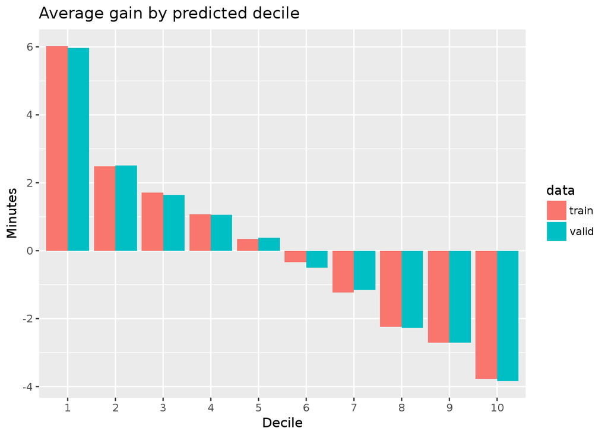

```r
# Plot average gains by predicted decile
deciles %>%
  ggplot(aes(factor(decile), gain, fill = data)) +
  geom_bar(stat = 'identity', position = 'dodge') +
  labs(title = 'Average gain by predicted decile', x = 'Decile', y = 'Minutes')
```

## Visualize predictions

Compare actual gains to predicted gains for an out of time sample.

```r
# Select data from an out of time sample
data_2008 <- flights_tbl %>%
  filter(!is.na(arrdelay) & !is.na(depdelay) & !is.na(distance)) %>%
  filter(depdelay > 15 & depdelay < 240) %>%
  filter(arrdelay > -60 & arrdelay < 360) %>%
  filter(year == 2008) %>%
  left_join(airlines_tbl, by = c("uniquecarrier" = "code")) %>%
  mutate(gain = depdelay - arrdelay) %>%
  select(year, month, arrdelay, depdelay, distance, uniquecarrier, description, gain, origin, dest)
data_2008
```

```
## # Source:   lazy query [?? x 10]
## # Database: spark_connection
##     year month arrdelay depdelay distance uniquecarrier description   gain
##    <int> <int>    <int>    <int>    <int> <chr>         <chr>        <int>
##  1  2008     1        2       19      810 WN            Southwest A…    17
##  2  2008     1       34       34      515 WN            Southwest A…     0
##  3  2008     1       11       25      688 WN            Southwest A…    14
##  4  2008     1       57       67     1591 WN            Southwest A…    10
##  5  2008     1       80       94      828 WN            Southwest A…    14
##  6  2008     1       15       27     1489 WN            Southwest A…    12
##  7  2008     1       16       28      838 WN            Southwest A…    12
##  8  2008     1       37       51      220 WN            Southwest A…    14
##  9  2008     1       19       32      220 WN            Southwest A…    13
## 10  2008     1        6       20      220 WN            Southwest A…    14
## # ... with more rows, and 2 more variables: origin <chr>, dest <chr>
```

```r
# Summarize data by carrier
carrier <- sdf_predict(ml1, data_2008) %>%
  group_by(description) %>%
  summarize(gain = mean(gain), prediction = mean(prediction), freq = n()) %>%
  filter(freq > 10000) %>%
  collect()
carrier
```

```
## # A tibble: 18 x 4
##    description                    gain prediction    freq
##    <chr>                         <dbl>      <dbl>   <dbl>
##  1 Endeavor Air Inc.             0.458    -0.596   35039.
##  2 SkyWest Airlines Inc.        -1.23     -0.0663  85859.
##  3 PSA Airlines Inc.            -2.28      0.410   36958.
##  4 United Air Lines Inc.         2.02      0.588   97408.
##  5 Frontier Airlines Inc.       -0.398     0.202   14674.
##  6 ExpressJet Airlines Inc. (1) -0.330    -2.81    70037.
##  7 Southwest Airlines Co.        4.18      4.01   224655.
##  8 ExpressJet Airlines Inc.      0.539     1.32    56247.
##  9 Continental Air Lines Inc.    2.36     -0.671   61386.
## 10 Northwest Airlines Inc.      -2.85     -2.11    49220.
## 11 JetBlue Airways              -0.975    -0.577   38257.
## 12 AirTran Airways Corporation  -1.92     -1.14    44867.
## 13 US Airways Inc.               2.40      0.468   59418.
## 14 Envoy Air                    -2.54     -2.50    97086.
## 15 Alaska Airlines Inc.          1.48      1.95    23806.
## 16 Delta Air Lines Inc.         -1.42     -1.58    69066.
## 17 Mesa Airlines Inc.            0.246     2.25    48208.
## 18 American Airlines Inc.       -0.688    -0.893  131798.
```

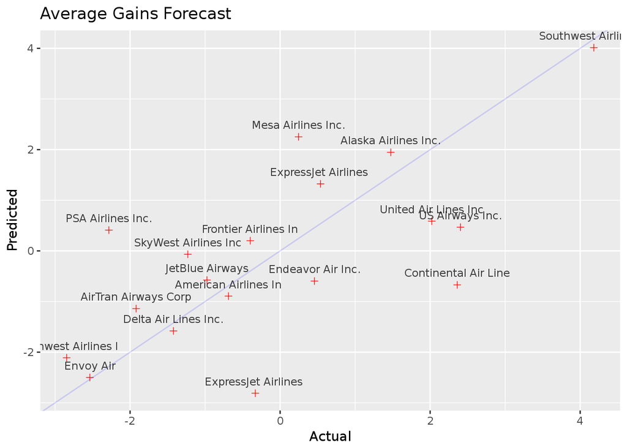

```r
# Plot actual gains and predicted gains by airline carrier
ggplot(carrier, aes(gain, prediction)) +
  geom_point(alpha = 0.75, color = 'red', shape = 3) +
  geom_abline(intercept = 0, slope = 1, alpha = 0.15, color = 'blue') +
  geom_text(aes(label = substr(description, 1, 20)), size = 3, alpha = 0.75, vjust = -1) +
  labs(title='Average Gains Forecast', x = 'Actual', y = 'Predicted')
```

## Disconnect from Spark

```r
spark_disconnect_all()
```

```
## [1] 1
```